# Calendar plot in R using ggplot2

庄亮亮

2020-12-04

# 前言

一眨眼2020即将过去，2020年是杂乱的一年，感谢我们还活着。让我们放下这年，展望2021年吧。要不用R给2021年做个私人定制版日历吧？

翻了翻张杰老师的可视化书，咦，确实有这么一小节讲诉用`ggplot2`做的日历图。再次就不做过多的描述，文章链接为：R-ggTimeSeries | ggplot2: 热力日历图。但是对于R小白的我而言，私人定制2021年日历，不简单啊。

找了下必应，找到了下面这个包，强烈给R小白安利，简单几行代码就可以实现私人化日历定制了，还可以打印出来，挂在书桌旁。

`calendR`包允许创建一个可定制的日历。此外，该软件包还提供了创建热图类型日历的参数。在本教程中，你将学习如何在R中创建年度和月度日历图。

# R中的年历图

该软件包非常易容易使用，因为它仅包含一个命名函数`calendR`。默认情况下，如果未指定任何参数，则该函数将以横向形式创建当年的日历，并且所有文本将使用系统的语言，如下所示：

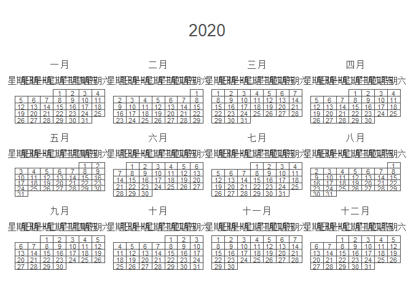

```r
# install.packages("calendR") #直接install安装包
library(calendR)
calendR() # 默认为当前年份
```

如果您不希望日历使用操作系统的语言，则可以对其进行修改。例如，如果您希望日历使用英语，则在执行calendR之前输入：

```r
# Sys.setlocale("LC_ALL","English")
```

如果您希望创建其他年份的年度日历图，则可以在`year`参数上指定它，如下所示：

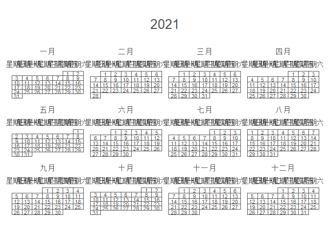

```r
calendR(year = 2021)
```

在以下小节中，我们将讨论如何在星期日或星期一开始，以及如何为某些日子添加颜色。

## 日历周开始的设定

日历的周数默认情况下将从星期日开始。可以将参数`start`设置为“M”来获得从星期一开始日历图。

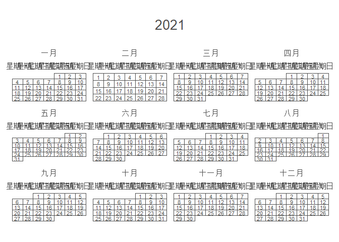

```r
calendR(year = 2021,
        start = "M") # Start the week on Monday
```

## 为日子增添色彩

该`special.days`参数将为数字矢量内的指定日期添加颜色。`special.col`设置颜色，`low.col`设置其他日期的颜色。

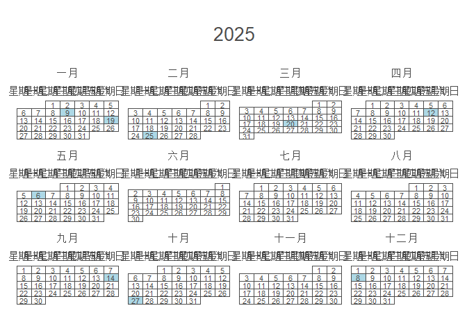

```r
calendR(year = 2025,
        start = "M",
        special.days = c(9, 19, 56, 79, 102,  # Days to color
                         126, 257, 300, 342),
        special.col = "lightblue",            # Color of the specified days
        low.col = "white")                    # Background color of the rest of the days
```

如果要突出显示日历中的所有周末，可以将`special.days`参数设置为`"weekend"`，此快捷方式将立即为它们全部着色。

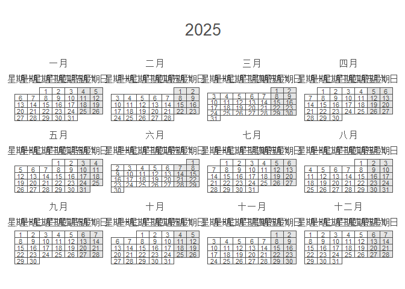

```r
calendR(year = 2025,
        start = "M",
        special.days = "weekend") # Color all weekends
```

为了添加多个事件，您将需要创建一个NA值向量，该向量的长度与相应年份的天数相同。然后，您可以将事件添加到矢量上一年中相应的日期，您需要在`special.days`参数中指定这些事件。请注意，您将需要指定与事件一样多的颜色。

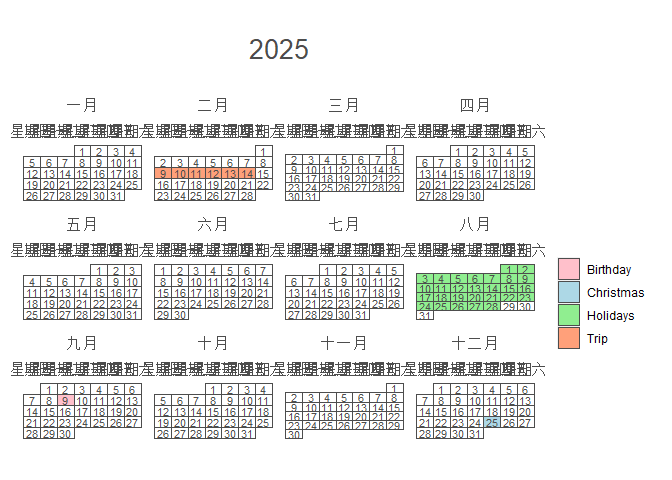

```r
# Vector of NA of the same length of the number of days of the year
events <- rep(NA, 365)

# Set the corresponding events
events[40:45] <- "Trip"
events[213:240] <- "Holidays"
events[252] <- "Birthday"
events[359] <- "Christmas"

# Creating the calendar with a legend
calendR(year = 2025,
        special.days = events,
        special.col = c("pink", "lightblue", # Colors
                        "lightgreen", "lightsalmon"),
        legend.pos = "right") # Legend to the right
```

# R中的月历图

年度日历的先前描述的功能也可用于每月日历。但是，如果需要，每月日历还可以将文本添加到每月的某几天。

为了创建月度日历，您需要指定年份和月份，如下所示：

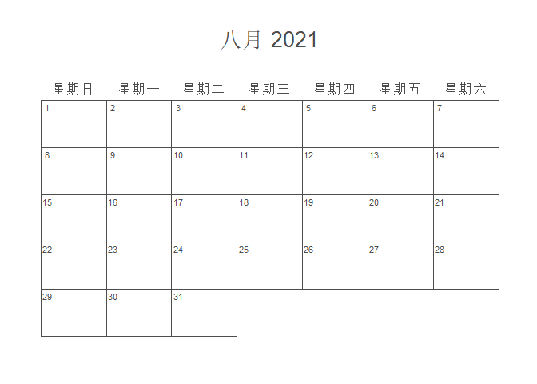

```r
calendR(year = 2021, month = 8)
```

## 为日子增添色彩

如前一节所述，您可以添加special.days参数中指定的日期的颜色。

一方面，对于只有一个事件，彩色的日子将是special.days参数中指定的日期，而颜色将是与special.col参数一起选择的日期。您还可以指定special.days = “weekend”在所有周末着色。

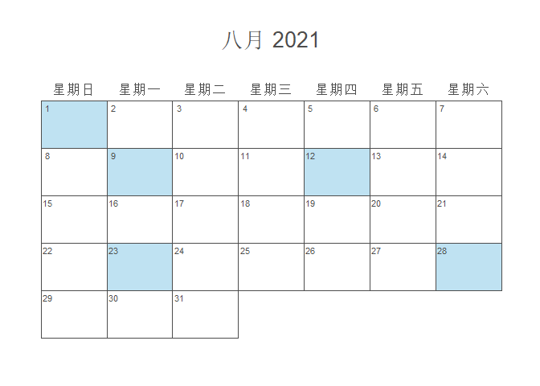

```r
calendR(year = 2021, month = 8,
        special.days = c(1, 9, 12, 23, 28),
        special.col = "#bfe2f2",
        low.col = "white")
```

## 在日子里添加文字

使用月度日历图时，您还可以使用text参数向日期添加一些文本，并使用参数指定其位置（日期）text.pos。请注意，您可以分别使用text.size和text.col参数修改文本的大小和颜色。

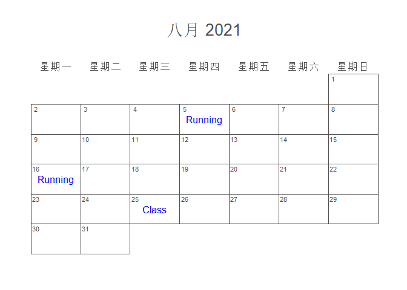

```r
calendR(year = 2021, month = 8,        # Year and month
        start = "M",                   # Start the week on Monday
        text = c("Running", "Running", # Add text (only for monthly calendars)
                 "Class"),
        text.pos = c(5, 16, 25),       # Days of the month where to put the texts
        text.size = 4.5,               # Font size of the text
        text.col = 4)                  # Color of the texts
```

## ggplot2中的农历

如果创建月度日历，则还可以将月相添加到其日期中。为此，请lunar = TRUE使用lunar.size参数设置并修改卫星的大小。您还可以使用参数更改卫星隐藏区域的颜色lunar.col。

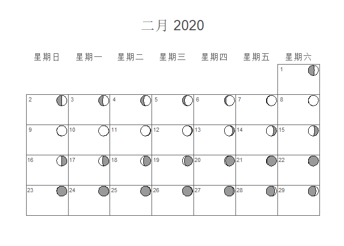

```r
calendR(month = 2,
        lunar = TRUE,         # Add moons to the calendar
        lunar.col = "gray60", # Color of the non-visible area of the moons
        lunar.size = 7)       # Size of the moons
```

# 学术日历

在start_date和end_date论据是创建学术日历特别有用。请参阅以下示例：

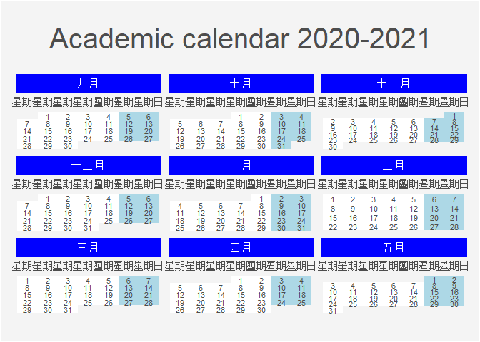

```r
calendR(start_date = "2020-09-01", # Custom start date
        end_date = "2021-05-31",   # Custom end date
        start = "M",               # Start the weeks on Monday
        mbg.col = 4,               # Color of the background of the names of the months
        months.col = "white",      # Color text of the names of the months
        special.days = "weekend",  # Color the weekends
        special.col = "lightblue", # Color of the special.days
        lty = 0,                   # Line type
        bg.col = "#f4f4f4",        # Background color
        title = "Academic calendar 2020-2021", # Title
        title.size = 30,                       # Title size
        orientation = "p")         # Vertical orientation
```

# 日历图的进一步定制

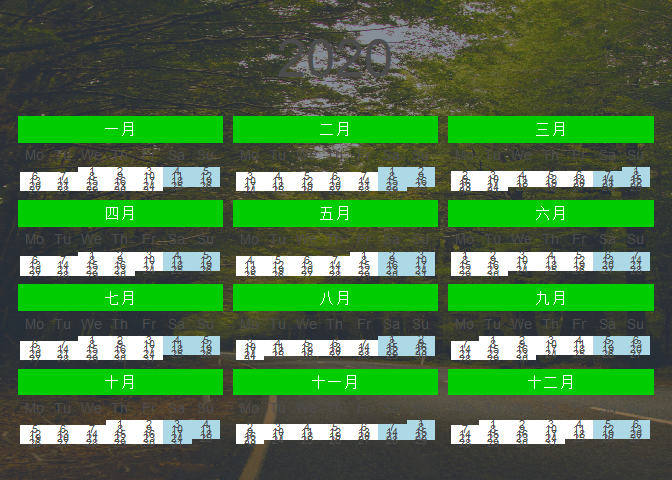

```r
# Background image (link or source file)
# If the image is from a local source it must be on the working directory,
# in other case you must indicate the full path
img <- "C:/Users/ZLL/Desktop/1.png"

calendR(start = "M",               # Weeks start on Monday
        mbg.col = 3,               # Background color of the month names
        months.col = "white",      # Color of the text of the month names
        special.days = "weekend",  # Color the weekends
        special.col = "lightblue", # Color of the special.days
        lty = 0,                   # Line type (no line)
        weeknames = c("Mo", "Tu",  # Week names
                      "We", "Th",
                      "Fr", "Sa",
                      "Su"),
        title.size = 40,   # Title size
        orientation = "p",
        bg.img = img)
```

# 将日历另存为PDF格式

最后，您可以将参数设置pdf为TRUE以准备打印的PDF格式（默认为A4格式）保存日历。

您也可以在doc_name参数中指定生成的PDF文件的名称，但如果未指定，则文件名的格式应为：Calendar_year.pdf年历或Calendar_month_year.pdf月历。例如，您可以使用以下代码在R中保存一个四列年度日历图：

```r
# calendR(year = 2021,
#         orientation = "landscape", # Set orientation = "portrait" for a three column calendar
#         pdf = TRUE,
#         doc_name = "My_calendar1")  # Name of the PDF (don't write the extension)
```

此外，您可以在几种纸张尺寸之间进行选择以保存日历，从“A6”到，“A0”但是请注意，您可能需要微调一些字体尺寸以获得所需的输出。

```r
# calendR(year = 2021,
#         orientation = "landscape",
#         pdf = TRUE,
#         papersize = "A6") # Choose the paper size
```